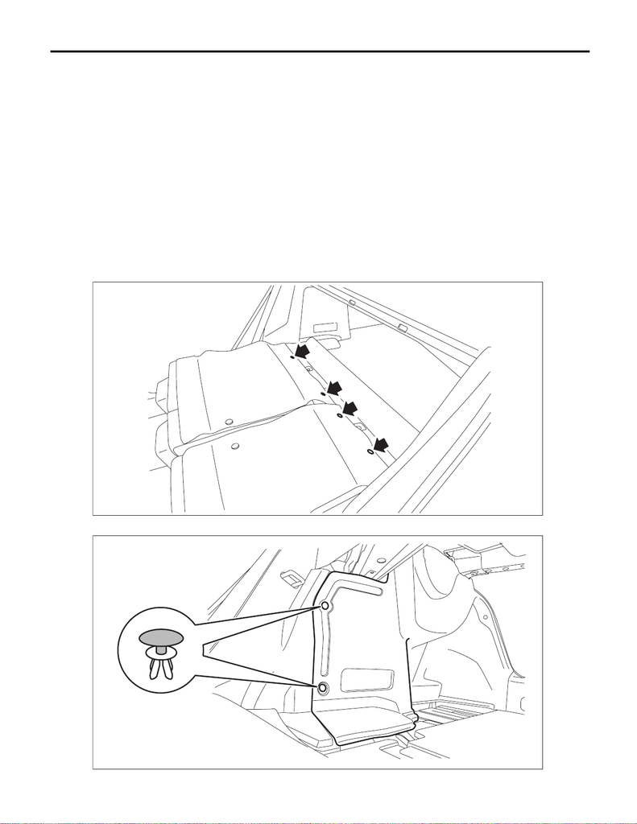

VDC-31

Rear ABS Wheel Speed Sensor

VEHICLE DYNAMICS CONTROL (VDC)

10.Rear ABS Wheel Speed Sensor

A: REMOVAL

1) Disconnect the ground cable from battery. <Ref. to NT-5, BATTERY, NOTE, Note.>

NOTE:

For models other than STI model, disconnect the ground terminal from battery sensor.

2) Lift up the vehicle, and then remove the rear wheels.

3) Remove the rear ABS wheel speed sensor.

CAUTION:

• Be careful not to damage the sensor.

• Do not apply excessive force to the sensor harness.

• Leave the sensor harness clamp (white arrow) on the vehicle side.

(1) Take out the trunk mat.

(2) Tilt the backrest assembly of the rear seat forward.

seat back.

(4) Remove the clips, and turn over the trim panel - trunk side.

SE-01309

RS-00409

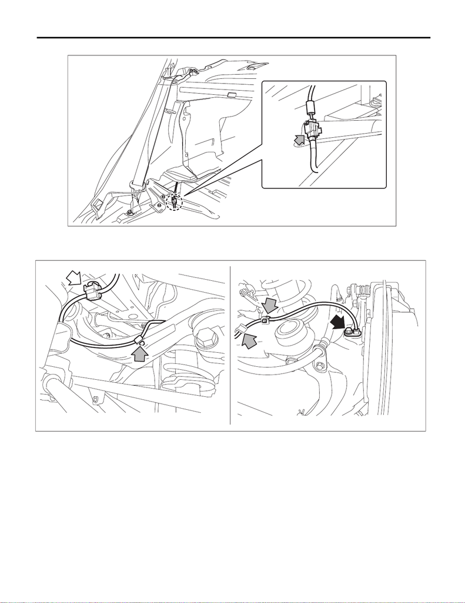

Rear ABS Wheel Speed Sensor

VEHICLE DYNAMICS CONTROL (VDC)

(5) Disconnect the connector of the rear ABS wheel speed sensor.

speed sensor.

(7) Remove the clip and bolt on the harness clamp, and remove the rear ABS wheel speed sensor.

VDC01326

VDC01039

[figure not shown]

Rear ABS Wheel Speed Sensor

VEHICLE DYNAMICS CONTROL (VDC)

B: INSTALLATION

CAUTION:

• Be careful not to damage the sensor.

• Do not apply excessive force to the sensor harness.

• Securely install the sensor harness to the rear upper arm assembly bracket.

1) Install the rear ABS wheel speed sensor.

NOTE:

CATION, General Description.>

Tightening torque:

Rear ABS wheel speed sensor: 7.5 N·m (0.8 kgf-m, 5.5 ft-lb)

2) Install the rear wheels.

Tightening torque:

Rear wheel: 120 N·m (12.2 kgf-m, 88.5 ft-lb)

3) Lower the vehicle.

4) Connect the battery ground terminal. <Ref. to NT-5, BATTERY, NOTE, Note.>

NOTE:

For models other than STI model, connect the ground terminal to battery sensor.

C: INSPECTION

1. ABS WHEEL SPEED SENSOR

For inspection of rear ABS wheel speed sensor, refer to inspection of front ABS wheel speed sensor. <Ref.

to VDC-30, CHECK ABS WHEEL SPEED SENSOR UNIT, INSPECTION, Front ABS Wheel Speed Sensor.>